# Device Monitoring, Sample and Element Precision for Analytical Data in handheld pXRF studies - Evaluation in R

Supplementary Material to Schauer 2026

Author

Affiliations

Michaela Schauer

Vienna Institute for Archaeological Science (VIAS), University of Vienna, Franz-Klein-Gasse 1, 1190 Vienna, Austria

Naturhistorisches Museum Wien (NHMW), Burgring 7, 1010 Vienna, Austria

Research Network Human Evolution und Archaeological Sciences (HEAS), University of Vienna, Djerassiplatz 1, 1030 Vienna, Austria

Published

January 31, 2026

## 1 Introduction

### 1.1 Content & Aim

This R script contains workflow and example data of the conference proceedings **Methodological Innovations in pXRF studies** (Schauer, Cantin, and Faucher 2026) **chapter 1 Workflow and Benchmarks for Daily Device Monitoring and Data Precision Assessment in handheld pXRF Studies** developed by M. Schauer, focusing on daily device monitoring, element and sample measurement precision. The methodology is discussed in more detail in Schauer (2026).

The script uses example data, demonstrating the calculations and providing brief explanations of the results for each method.

**Precision Assessment (see Section 4 and Section 5)**

The script evaluates element and sample precision:

- *LOD & LOQ* is used to identify reliable elements (see Section 4):

To monitor the percentage of LOD per element as provided by the device (< LOD instead of value) a plot is generated (see Section 4.1).

The LOD/LOQ calculation is based on the following steps (see Section 4.2):

- Ten replicate measurements per standard on the same measurement spot to catch statistical random error
- SDMean(1δSD) is calculated per element and standard for the device-reported measurement uncertainties (error values). Mean, Standard Deviation (SD) and Coefficient of Variation (CV - see below) are provided as well.
- MeanSD is calculated across all three standards. Additionally, Median, SD and CV are provided.
- Empirical LOD is calculated as 3*MeanSD
- Empirical LOQ is calculated as 3.3*LOD

The basis of these calculations are three standards provided by the producer for silicate matrices (see Section 1.4).

In the next step, a table summing up violations of the empirical LOQ for all measurements and elements is created (see Section 4.3)

To monitor the percentage of empirical LOQ per element a plot is provided individually (see Section 4.4) but also in combination with the LOD monitoring plot (see Section 4.6). In both cases, 20% of violations are defined as the cut-off point - elements above this threshold are considers as not reliable for quantitative analysis.

This is accompanied by and export of fully reliable (no violation of empirical LOQ) and elements flagging at least one value < empirical LOQ (see Section 4.5).

It has to be stressed at this point, that elements frequently falling below detection or quantification thresholds can still yield valuable insights. While most samples may show values below LOD, a few may present detectable or even elevated concentrations, which can be archaeologically significant. However, before using such elements for interpretation, potential calibration errors or device malfunctions must be ruled out. Even if only usable qualitatively, all elements should be reviewed as part of the interpretive process.

- *Coefficient of Variation (CV)* is used to identify reliable elements and sample precision (see Section 5):

To ensure the reliable application of the procedures outlined here, LOD is replaced with ‘0.0000001’ (see Section 4, Section 5).

The CV is calculated based on an example pottery dataset (see Section 1.4) with repeated measurements of the same sample (generally three) to assess overall sample precision and determine which elements are reliable across the entire dataset (see Section 5). The CV-benchmark is set based on the material analysed. From the literature, a CV-benchmark of 15% for archaeological pottery, stone, daub and in-situ measurements of soil are appropriate. For obsidian, dried, fine-grained and homogenized powder of sediments measured in a measurement cup and pressed tablets, a CV of 10%, as suggested for highly homogeneous samples such as standards, can be applied. Additionally, no more than 20% of elements considered reliable for a sample may exceed the benchmarks.

The steps applied in this protocol are

- Calculate the CVs for all samples and the total mean CVs for all elements in the example data (see Section 5.1)
- Provide a color-coded spreadsheet export highlighting all CV>15% (see Section 5.2). This spreadsheet can be consulted during data interpretation to define the reliability of elements for specific samples which is especially important when identifying ouliers.
- Create a monitoring plot displaying the mean CVs for all elements individually (see Section 5.3) or combined with LOD and LOQ plots (see Section 5.4). For CV of this example, the benchmark is set at a maximum of 15%.
- Create number-codes spreadsheet with sample CVs below 15% substituted with “0” (no violation) and above 15% with “1” (benchmark violation) (see Section 5.5). Based on this file, sample violation percentage is calculated across reliable elements (see Section 5.6). Violating elements are defined by combining the results of LOD, LOQ and CV monitoring (see Section 5.4).
- Reliable (less then 20% of reliable elements with CV>15%) and violating samples (more then 20% of reliable elements with CV>15%) are identified (see Section 5.7).
- Create a spreadsheet of reliable and violating elements (see Section 5.8).
- Export of all relevant documentation: a list of reliable and unreliable elements, the complete spreadsheet with codes 0 (<15% CV) and 1 (>15% CV) for all elements and samples analysed including mean CVs for elements and a separate spreadsheet showing only reliable elements and highlighting samples with >20% violation of the CV benchmark for reliable elements (see Section 5.9).

**Daily Device monitoring (see Section 6)**

To monitor daily device performance, the following methods are employed:

- *Control Limits (nominal values)* are calculated to define the reference values for device monitoring based on the specific mode, the matrix to be analysed and the therefore selected standard (see Section 6.1).

Upper and Lower Control Limits are calculated at mean 1x2δSD, 2x2δSD and 3x2δSD. Additionally, CV and Standard Error of the Mean as well as the Median of the reference data is provided (see Section 6.1.1). The spreadsheet with all metrics is exported (see Section 6.1.2) with the optional addition of adding manufacturer and empirical LOD as well as empirical LOQ (see Section 6.1.2.1; data derived from Section 4.2). For visualisation, the difference of the mean Control Limit (nominal value) to LOQ, two plots of difference (see Section 6.1.2.2) and Percent Relative Difference (%RD; see also Section 6.1.1) are provided (see Section 6.1.2.3). LODs and LOQ can be added to the data export as well (see Section 6.1.2.4).

As additional export option, a spreadsheet of the selected elements for rapid on-screen daily device monitoring for the specific mode and material is provided (see also Schauer (2026) (see Section 6.1.3). 2/3 out of the selected elements with CV ≤ 10% (1δSD) have to fall in the defined Control Limits.

- *Shewhart Control Charts (SCCs)* are constructed using said reference values to monitor device performance (see Section 6.2).

In the first step, the spreadsheet created in Section 6.1.2 respective Section 6.1.2.1 is re-formatted (see Section 6.2.1).

Following this, SCCs are created to visually monitor short-term s-drift (see Section 6.2.2) and long-term l-drift (see Section 6.2.3).

- *Relative Percentage Difference (%RD)* is calculated to further evaluate device performance in regard to accuracy (see Section 6.3). The %RD hast to be below 10% and above -10%.

The %RD is calculated and prepared as a spreadsheet (see Section 6.3.1). Optionally, empirical LOD and Control Limit mean can be added (see Section 6.3.1.1).

Based on this, a color-coded spreadsheet for export (see Section 6.3.2) and visualisation of %RD through plots is created (see Section 6.3.3).

**Conclusion (see Section 7)**

The conclusion gives a summary of the results based on the example data and the potential benefit of this script for handeld pXRF studies.

### 1.2 Skript & Packages

This Quarto script (R Quarto v.1.5.55) (Allaire et al. 2024) was created using R v.4.4.1 (R Core Team 2024) and RStudio v.2024.04.2 (RStudio Team 2024). The following R packages are employed:

- basictabler (Bailiss 2021)
- dplyr (Wickham and Henry 2023)
- ggpubr (Kassambara 2023)
- ggplot2 (Wickham 2016)
- openxlsx (Schauberger and Walker 2024)
- purrr (Wickham et al. 2023)
- qcc (Scrucca 2004)
- readr (Wickham, Vaughan, and Girlich 2024)
- tidyr (Wickham, Hester, and Bryan 2024)
- stringr (Wickham and Henry 2023)

Before running the analyses, all packages must be loaded (see Section 2) and the working directory set (see Section 3).

The script runs without errors, provided the predefined data structure is maintained.

### 1.3 Device & Measurement Parameters

Data for this protocol was collected using the Bruker Tracer 5g (serial no. 900G6390) of the Vienna Institute for Archaeological Science, operating in MudrockDual mode (Major (15kV/27.9μA, no filter): 60s; Trace (40kV/38.85μA, Ti 25μm/Al 300μm): 60s) with an 8 mm collimator. The device is equipped with a 20 mm² silicon drift detector (SDD) and a graphene window, providing an energy resolution of <140eV at 250.000 cps (measured at MnKα). Measurements were conducted between 26 February and 14 May 2025 (30–45% rel.hum.; 20–27°C), as part of the FWF ESPRIT Project 476 *Standardising Portable X-ray Fluorescence for Archaeometry* (Schauer 2023).

### 1.4 Standards & Samples

The dataset includes pottery samples created for experimental purposes in the scope of ESP 476 (Schauer 2023) and reference standards (SiO2, Mudrock Standard, SdAR-M2 (International Association of Geoanalysts 2017)) supplied by the manufacturer. Where the device output reported measurement values as “< LOD”, a placeholder value of 0.0000001 was used to retain data structure and enable downstream analysis.

For the element and sample precision example (Section 4 and Section 5) the pottery samples were measured three times at non-overlapping positions, the 10-fold standard measurements on the same position. Repeated measurements for the example data for device testing were carried out on the powder Standard SdAR-M2 on the same measurement position (see Section 6).

### 1.5 Manufacturer LOD

For the settings used in this study (see Section 1.3), no manufacturer-provided LODs were available. However, the supplier provided a guide for manually calculating LODs from the calibration spectra specific to the device. The author followed this guide, applying the ASTM E2926 standard to generate the values (ASTM International - E30.01 Committee 2017), and is grateful to Josef Schuller and Dr. Kathrin Schneider for their support and guidance throughout this process.

### 1.6 Funding

This research was funded by the Austrian Science Fund (FWF) 10.55776/ESP476 (Schauer 2023).

## 2 Packages

**Background**

After https://www.projectpro.io/recipes/load-package-r and https://www.dataquest.io/blUCL/install-package-r/

```r
library(basictabler)
library(dplyr)
library(ggpubr)
library(ggplot2)
library(openxlsx)
library(purrr)
library(qcc)
library(readr)
library(stringr)
library(tidyr)
```

## 3 Set working directory

**Background**

After https://martinctc.github.io/blUCL/rstudio-projects-und-working-directories-a-beginner%27s-guide/, https://www.grainge.org/pages/authoring/relative_paths/relative_paths.htm and https://r4ds.had.co.nz/workflow-projects.html

```r
knitr::opts_knit$set(root.dir = "./")
```

## 4 Article Section 3.1 - monitoring LOD and LOQ for element precision

### 4.1 Create monitoring LOD plot

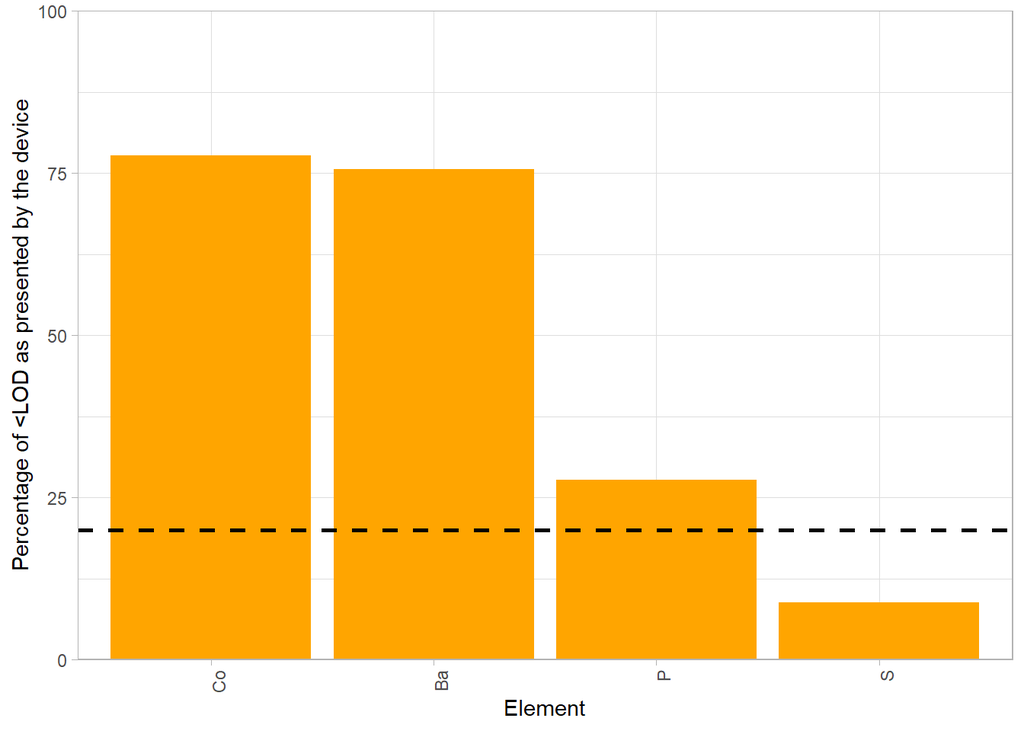

```r
# Load data
data1 <- read_csv("../data_analytical/Example_data_precision.csv")

# Filter data
data2 <- data1 %>%
  select(!contains(" Err"))
data <- data2[, c(17:40)]

# Calculate LOD proportion per element
LOD_proportions <- data|>
  dplyr::select(where(~ any(grepl("< LOD", .))))  |> # Keep only columns containing "<LOD"
  summarise(across(everything(), ~ sum(grepl("< LOD", .)) / n()*100)) |>  # Calculate proportion of "<LOD" per column
  pivot_longer(everything(), names_to = "Element", values_to = "Proportion_LOD") |>  # Convert to long format
  arrange(desc(Proportion_LOD))  # Sort by proportion in descending order

# Create Diagram
LOD_plot<-ggplot(LOD_proportions, aes(x = reorder(Element, -Proportion_LOD), y = Proportion_LOD)) +
  geom_bar(stat = "identity", fill = "orange") +
  labs(x = "Element",y = "Percentage of <LOD as presented by the device",) +
  theme_light()+
  scale_y_continuous(limits = c(0, 100), expand = c(0, 0)) +
  geom_hline(yintercept = 20, color = "black", linetype = "dashed", linewidth = 1)+
  theme(axis.text.x = element_text(angle = 90, hjust = 1))

# View plot
print(LOD_plot)
```

**Interpretation**: Monitoring the LOD presented by the device based on the measurement mode revealed the elements Co and Ba as clearly violating the benchmark of 20% of measurement values per element below LOD with P and S needing to be evaluated further.

### 4.2 Calculate Empirical LOD & LOQ from Standard Measurements

```r
# Load data
data7 <- read_csv("../data_analytical/Example_data_LOD.csv")

# Standardise Measurement Uncertainty from 2Sgima to 1Sigma
data8 <- data7 %>%
  mutate(across(ends_with(" Err"), ~ . / 2))

# Standardise Measurement Uncertainty from 1Sgima to 3Sigma
data <- data8 %>%
  mutate(across(ends_with(" Err"), ~ . * 3))

# Calculate mean, SD and CV of Measurement Uncertainty per sample and element
data1 <- data %>%
  group_by(SAMPLE) %>%
  summarise(
    across(
      .cols = ends_with(" Err"),
      .fns = list(
        Mean = ~ mean(.x, na.rm = TRUE),
        SD   = ~ sd(.x, na.rm = TRUE),
        CV   = ~ sd(.x, na.rm = TRUE) / mean(.x, na.rm = TRUE)*100
      ),
      .names = "{.col}_{.fn}"
    )
  )

# Convert % to ppm and round results
data2 <- data1 %>%
  mutate(across(
    .cols = where(is.numeric) & !matches("_CV$"),
    .fns = ~ .x * 10000
  )) %>%
  mutate(across(matches("_CV$"), ~ round(.x, 2))) %>%
  mutate(across(matches("_SD$|_Mean$"), ~ round(.x, 0)))

# Clean column names
colnames(data2)[-1] <- str_replace(colnames(data2)[-1], "\\ Err", "")

# Reshape: metric as rows, samples as columns
data3 <- data2 %>%
  pivot_longer(
    cols = -SAMPLE,
    names_to = "metric",
    values_to = "value"
  ) %>%
  pivot_wider(
    names_from = SAMPLE,
    values_from = value
  )

# Compute LOD (3×SD), LOQ (3.3×LOD) across standards
data4 <- data3 %>%
  rowwise() %>%
  mutate(
    Element_mean = round(mean(c_across(2:last_col()), na.rm = TRUE), 0),
    Element_median = round(median(c_across(2:last_col()), na.rm = TRUE), 0),
    Element_SD   = round(sd(c_across(2:last_col()), na.rm = TRUE), 0),
    Element_CV   = round((Element_SD/Element_mean) * 100, 0)
  ) %>%
  ungroup() %>%
  mutate(
    Empirical_LOD = round(3 * Element_mean, 0),
    Empirical_LOQ = round(3.3 * Empirical_LOD, 0)
  )


# Manufacturer-defined LODs (must match the metric names, e.g., "Fe_Mean")
lod_table <- tibble::tibble(
  metric = c("Na_Mean", "Mg_Mean", "Al_Mean", "Si_Mean", "P_Mean", "S_Mean", "K_Mean", "Ca_Mean", "Ti_Mean",
             "V_Mean", "Cr_Mean", "Mn_Mean", "Fe_Mean", "Co_Mean", "Ni_Mean", "Cu_Mean", "Zn_Mean", "As_Mean",
             "Rb_Mean", "Sr_Mean", "Y_Mean", "Zr_Mean", "Nb_Mean", "Mo_Mean", "Ba_Mean", "Pb_Mean", "Th_Mean", "U_Mean"),
  Manufacturer_LOD = c(892, 404, 111, 56, 12, 32, 16, 14, 8, 2, 3,
            10, 8, 0, 3, 1, 2, 2,2,2,2,1,3,4,17,14,2,2)
)

# Merge
data5 <- data4 %>%
  left_join(lod_table, by = "metric") %>%
  relocate(Empirical_LOD, Manufacturer_LOD, Empirical_LOQ, .after = Element_CV)

# Print data
print(data5)
```

```
# A tibble: 81 × 11
   metric  `Mudrock Standard` `SdAR-M2`    SiO2 Element_mean Element_median
   <chr>                <dbl>     <dbl>   <dbl>        <dbl>          <dbl>
 1 Mg_Mean            1677      1489    1128            1431           1460
 2 Mg_SD                38        24      13              25             24
 3 Mg_CV                 2.25      1.6     1.17            2              2
 4 Al_Mean            1197       916     290             801            858
 5 Al_SD                34        27       2              21             24
 6 Al_CV                 2.84      2.91    0.74            2              2
 7 Si_Mean            1208      1241    1208            1219           1214
 8 Si_SD                41        41       4              29             35
 9 Si_CV                 3.4       3.31    0.3             2              3
10 P_Mean               79        88      65              77             78
# ℹ 71 more rows
# ℹ 5 more variables: Element_SD <dbl>, Element_CV <dbl>, Empirical_LOD <dbl>,
#   Manufacturer_LOD <dbl>, Empirical_LOQ <dbl>
```

```r
# Save the LOD/LOQ results
write_csv(data5, "../data_analytical/Example_data_empirical_LOD_LOQ.csv")
```

### 4.3 Flagg Measurement Values below LOQ

```r
# Load data
data5 <- read_csv("../data_analytical/Example_data_empirical_LOD_LOQ.csv")

# Get LOQ values, clean up metric names
data_loq <- data5 %>%
  filter(!is.na(Empirical_LOQ)) %>%
  mutate(metric = str_replace(metric, "_Mean$", "")) %>%
  select(metric, Empirical_LOQ) %>%
  pivot_wider(names_from = metric, values_from = Empirical_LOQ)

loq_vector <- as.list(data_loq[1, ])  # Named list of LOQ values

# Load sample measurement data
data6 <- read_csv("../data_analytical/Example_data_precision.csv")

# Clean and scale the measurement data
data7 <- data6 %>%
  mutate(across(17:71, ~ case_when(
    . == "< LOD" ~ "0.0000001",
    TRUE ~ as.character(.)
  ))) %>%
  mutate(across(17:71, ~ as.numeric(.))) %>%
  mutate(across(17:71, ~ case_when(
    . >= 0.0000001 ~ . * 10000,  # Convert % to ppm
    TRUE ~ .
  )))

# Select measurement data + SAMPLE
data_cleaned <- data7[, c("SAMPLE", names(data7)[17:70])]

# Clean column names
data_cleaned <- data7[, c("File", names(data7)[17:70])]
names(data_cleaned) <- names(data_cleaned) %>% str_replace_all(" ", ".")

# Apply LOQ checks
check_results <- data_cleaned

for (element in names(loq_vector)) {
  value_col <- element
  err_col <- paste0(element, ".Err")
  flag_col <- paste0(element, "_flag")

  if (!(value_col %in% names(check_results)) || !(err_col %in% names(check_results))) {
    warning(paste("Skipping", element, "- column missing"))
    next
  }

  loq <- loq_vector[[element]]

  check_results[[flag_col]] <- case_when(
    is.na(check_results[[value_col]]) | is.na(check_results[[err_col]]) ~ NA_character_,
    check_results[[value_col]] < loq &
      (check_results[[value_col]] - check_results[[err_col]]) < loq ~ "[LOW][LOW-ERR]",
    check_results[[value_col]] < loq ~ "[LOW]",
    (check_results[[value_col]] - check_results[[err_col]]) < loq ~ "[LOW-ERR]",
    TRUE ~ ""
  )
}

# Keep only rows and columns with at least one flag
flag_columns <- names(check_results)[str_ends(names(check_results), "_flag")]

# Filter rows with any flag present
filtered_flags <- check_results %>%
  filter(if_any(all_of(flag_columns), ~ . != "")) %>%
  select(File, all_of(flag_columns))

# Count flags per column, convert to character
flag_summary_row <- filtered_flags %>%
  select(-File) %>%
  summarise(across(everything(), ~ as.character(sum(. != "", na.rm = TRUE))))

# Add File label to mark the summary row
flag_summary_row <- tibble(File = "TOTAL_FLAGS", flag_summary_row)

# Make sure File is character in main data
filtered_flags <- filtered_flags %>%
  mutate(File = as.character(File))

# Combine
flag_results_with_total <- bind_rows(flag_summary_row, filtered_flags)

# View result
print(flag_results_with_total)
```

```
# A tibble: 91 × 28
   File      Mg_flag Al_flag Si_flag P_flag S_flag K_flag Ca_flag Ti_flag V_flag
   <chr>     <chr>   <chr>   <chr>   <chr>  <chr>  <chr>  <chr>   <chr>   <chr>
 1 TOTAL_FL… "69"    "0"     "0"     "78"   "61"   "0"    "0"     "0"     87
 2 3388      "[LOW]… ""      ""      "[LOW… ""     ""     ""      ""      [LOW]…
 3 3389      "[LOW]… ""      ""      "[LOW… ""     ""     ""      ""      [LOW]…
 4 3390      "[LOW]… ""      ""      "[LOW… ""     ""     ""      ""      [LOW]…
 5 3398      ""      ""      ""      ""     ""     ""     ""      ""      [LOW]…
 6 3399      ""      ""      ""      ""     ""     ""     ""      ""      [LOW]…
 7 3400      ""      ""      ""      ""     ""     ""     ""      ""      [LOW]…
 8 3401      "[LOW-… ""      ""      "[LOW… "[LOW… ""     ""      ""      [LOW]…
 9 3402      "[LOW]… ""      ""      "[LOW… "[LOW… ""     ""      ""      [LOW]…
10 3403      ""      ""      ""      "[LOW… "[LOW… ""     ""      ""      [LOW]…
# ℹ 81 more rows
# ℹ 18 more variables: Cr_flag <chr>, Mn_flag <chr>, Fe_flag <chr>,
#   Co_flag <chr>, Ni_flag <chr>, Cu_flag <chr>, Zn_flag <chr>, As_flag <chr>,
#   Rb_flag <chr>, Sr_flag <chr>, Y_flag <chr>, Zr_flag <chr>, Nb_flag <chr>,
#   Mo_flag <chr>, Ba_flag <chr>, Pb_flag <chr>, Th_flag <chr>, U_flag <chr>
```

```r
# Save data
write_csv(flag_results_with_total, "../data_analytical/Example_data_empirical_LOD_flaggedData.csv")
```

### 4.4 Monitor proportion of LOQ - Create LOQ plot

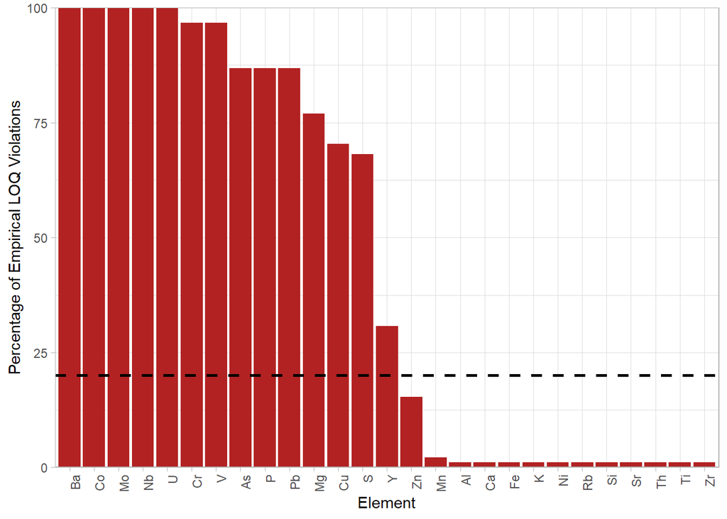

```r
# Load the flagged data
data <- read_csv("../data_analytical/Example_data_empirical_LOD_flaggedData.csv")

# Identify all _flag columns
flag_columns <- names(data)[str_ends(names(data), "_flag")]

# Calculate percentage of non-empty flags per column
LOQ_proportions <- data %>%
  summarise(across(all_of(flag_columns), ~ sum(. != "" & !is.na(.)) / n() * 100)) %>%
  pivot_longer(everything(), names_to = "Element", values_to = "Proportion_LOQ") %>%
  mutate(Element = str_remove(Element, "_flag$")) %>%
  arrange(desc(Proportion_LOQ))

# Create diagram
LOQ_plot <- ggplot(LOQ_proportions, aes(x = reorder(Element, -Proportion_LOQ), y = Proportion_LOQ)) +
  geom_bar(stat = "identity", fill = "firebrick") +
  labs(x = "Element", y = "Percentage of Empirical LOQ Violations") +
  theme_light()+
  scale_y_continuous(limits = c(0, 100), expand = c(0, 0)) +
  geom_hline(yintercept = 20, color = "black", linetype = "dashed", linewidth = 1)+
  theme(axis.text.x = element_text(angle = 90, hjust = 1))

# View plot
print(LOQ_plot)
```

**Interpretation**: The proportion per element of values below LOQ revealed the elements Ba, Co, Mo, Nb, U, Cr, V, As, P, Pb, Mg, Cu and S to violate the 20% benchmark, while Y needs further evaluation.

### 4.5 Export Element Report

```r
# Load the flagged data
data <- read_csv("../data_analytical/Example_data_empirical_LOD_flaggedData.csv")

# Identify all _flag columns
flag_columns <- names(data)[str_ends(names(data), "_flag")]

# Calculate proportion of non-empty flags per column
element_summary <- data |>
  summarise(
    across(
      all_of(flag_columns),
      ~ sum(. != "" & !is.na(.)) / n() * 100
    ) # Calculate percentage of flagged samples per element
  ) |>
    pivot_longer(
    everything(),
    names_to = "Element",
    values_to = "Proportion_LOQ"
  ) |> # Reshape into long format: one row per element

  mutate(
    Element = str_remove(Element, "_flag$"), # Remove "_flag" suffix
    Category = if_else(Proportion_LOQ > 20, "Violating Elements", "Reliable Elements") # Categorise elements as 'Violating' or 'Reliable' based on 20% threshold
  ) |>
    arrange(Category, desc(Proportion_LOQ)) |> # Sort elements within each category by descending proportion
    group_by(Category) |> # Combine element names into a single comma-separated string per category
  summarise(
    Elements = paste(Element, collapse = ", ")
  ) |>
  # Add row numbers to mimic 1: Reliable, 2: Violating output
  mutate(Row = row_number()) |>
  select(Row, Category, Elements)

# View final result
print(element_summary, n = Inf)
```

```
# A tibble: 2 × 3
    Row Category           Elements
  <int> <chr>              <chr>
1     1 Reliable Elements  Zn, Mn, Al, Si, K, Ca, Ti, Fe, Ni, Rb, Sr, Zr, Th
2     2 Violating Elements Co, Nb, Mo, Ba, U, V, Cr, P, As, Pb, Mg, Cu, S, Y
```

```r
# Save data
write_csv(element_summary, "../data_analytical/Example_data_LOQ_elements.csv")
```

### 4.6 Create combined LOD & LOQ monitoring plot

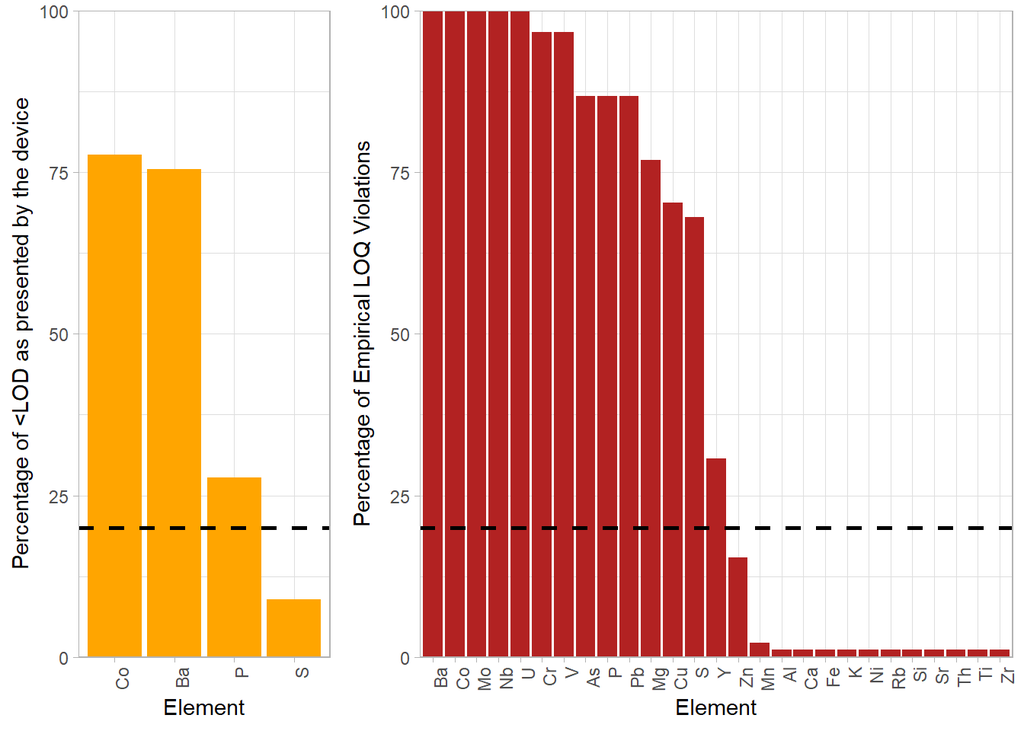

```r
# Combine LOD_plot and LOQ_plot side by side
combined_plot_LOQ_LOD <- ggarrange(
  LOD_plot,
  LOQ_plot,
  ncol = 2,
  widths = c(1, 2),
  align = "hv"
)

# View final result
print(combined_plot_LOQ_LOD)
```

```r
# Save as PDF
ggsave(
  filename = "../figures/LOD_LOQ_combined.eps",
  plot = combined_plot_LOQ_LOD,
  device = "pdf",
  width = 15,
  height = 8,
  units = "cm"
)
```

## 5 Article Section 3.2 - Monitor CV for element and sample precision

### 5.1 Create Spreadsheet with CVs

```r
# Load data
data1 <- read.csv("../data_analytical/Example_data_precision.csv")

# Replace LOD with 0.0000001
data2 <- data1 %>%
  mutate(across(17:71, ~ case_when(
    . == "< LOD" ~ "0.0000001",
    TRUE ~ as.character(.)
  ))) %>%
  mutate(across(17:71, ~ as.numeric(.)))


# Select relevant columns: SAMPLE + measurement values
data <- data2[, c(17:70,6)]

# CV function
CV <- function(x) { (sd(x) / mean(x)) * 100 }

# Calculate CV for each sample
SampleControl1 <- data %>%
  group_by(SAMPLE) %>%
  summarize(across(everything(), list(CV = CV)))

# Extract columns with "_CV"
cv_columns <- grep("_CV", colnames(SampleControl1), value = TRUE)
cv_columns <- cv_columns[!grepl("Err_CV", cv_columns)]

# Create a new dataframe with only the selected columns
SampleControl2 <- SampleControl1[, c(cv_columns)]

# Substitute infinite values, missing values and CV above 99% with 99
Control_CV <- lapply(SampleControl2, function(x) {
  x[is.na(x) |is.infinite(x) | x > 99] <- 99
  return(x)
})

# To rebind into a dataframe
Control_CV <- as.data.frame(Control_CV)

# Merge with Sample description
Control_CV1 <- Control_CV %>%
  mutate(SAMPLE = SampleControl1$SAMPLE)

# Calculate mean for each column (excluding SAMPLE)
mean_row <- Control_CV1 |>
  select(-SAMPLE) |>
  summarise(across(everything(), mean, na.rm = TRUE)) |>
  mutate(SAMPLE = "Mean")

# Add mean row to the top of the data and row SAMPLE to the front
Control_CV1_1 <- bind_rows(mean_row, Control_CV1) |>
  select(SAMPLE, everything())
```

### 5.2 Creating a benchmark-color-coded spreadsheet of CV-values

```r
# Create table
tbl <- BasicTable$new()
tbl$addData(Control_CV1_1, firstColumnAsRowHeaders=TRUE)

# Get the number of rows and columns in the dataset
num_rows <- nrow(Control_CV1_1)
num_columns <- ncol(Control_CV1_1)

# Find the index of the column with the header "SAMPLE"
sample_column_index <- which(names(Control_CV1_1) == "SAMPLE")

# Define the columns to style (excluding the 'SAMPLE' column)
column_indices_to_style <- setdiff(1:num_columns, sample_column_index)

# Ensure last row is included in styling
cells <- tbl$getCells(
  rowNumbers = 2:(num_rows + 1),
  columnNumbers = column_indices_to_style,
  matchMode = "combinations"
)

# Apply the styling
tbl$mapStyling(
  cells = cells,
  styleProperty = "background-color",
  valueType = "color",
  mapType = "logic",
  mappings = list(
    "v > 15", "firebrick",   # Values greater than 15%
    "v <= 15", "black"      # Values less than 15%
  )
)

# Render the table with applied styles
tbl$renderTable()
```

[interactive chart not shown]

```r
# Save the table to an Excel workbook
wb <- createWorkbook(creator = Sys.getenv("M. Schauer"))
addWorksheet(wb, "Data")
tbl$writeToExcelWorksheet(wb = wb, wsName = "Data", topRowNumber = 1, leftMostColumnNumber = 1, applyStyles = TRUE)

# Save the workbook
saveWorkbook(wb, file = "../data_analytical/Example_data_precision_colcode_all.xlsx", overwrite = TRUE)
```

**Comment**: This spreadsheet can be used to gain a better understanding of the severity of the benchmark violation. It is especially useful for interpreting outliers in the later stages of data analysis, to assess whether the elements defining an outlier were measured with sufficient precision.

### 5.3 Create CV-mean plot

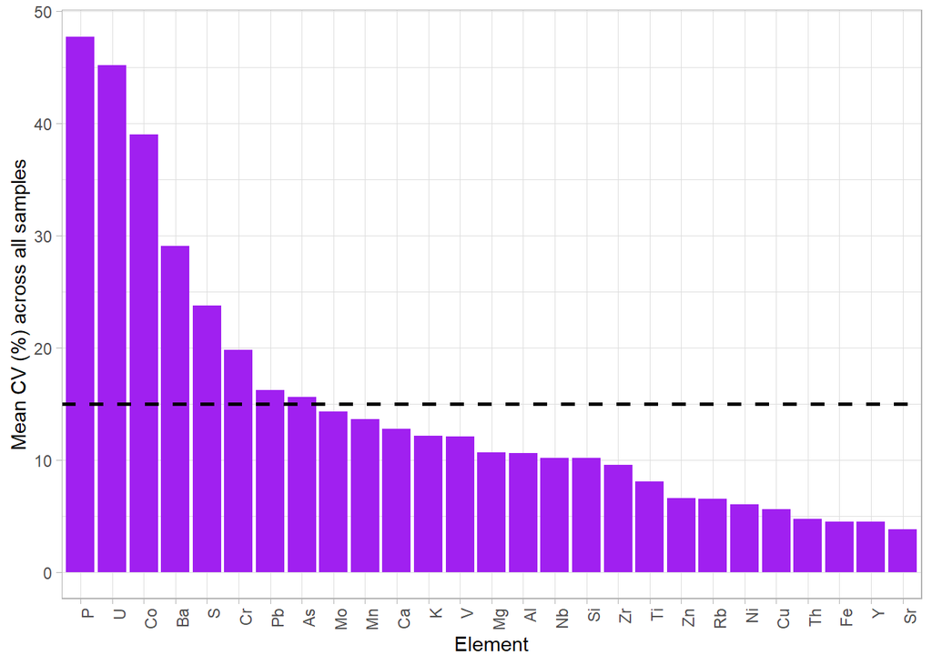

```r
# Extract and reshape mean row
mean_values <- Control_CV1_1[1, ] |>
  select(-SAMPLE) |>
  pivot_longer(
    cols = everything(),
    names_to = "Element",
    values_to = "Mean_CV"
  ) |>
  mutate(
    Element = gsub("_CV$", "", Element),   # Remove "_CV" suffix
    Mean_CV = round(Mean_CV, 2)
  )

# Create the bar plot
mean_cv_plot <- ggplot(mean_values, aes(x = reorder(Element, -Mean_CV), y = Mean_CV)) +
  geom_bar(stat = "identity", fill = "purple") +
  labs(
    x = "Element",
    y = "Mean CV (%) across all samples"
  ) +
  theme_light() +
  geom_hline(yintercept = 15, color = "black", linetype = "dashed", linewidth = 1) +
  theme(axis.text.x = element_text(angle = 90, hjust = 1))

# Show the plot
print(mean_cv_plot)
```

### 5.4 Create combined LOD, LOQ, CV monitoring plot

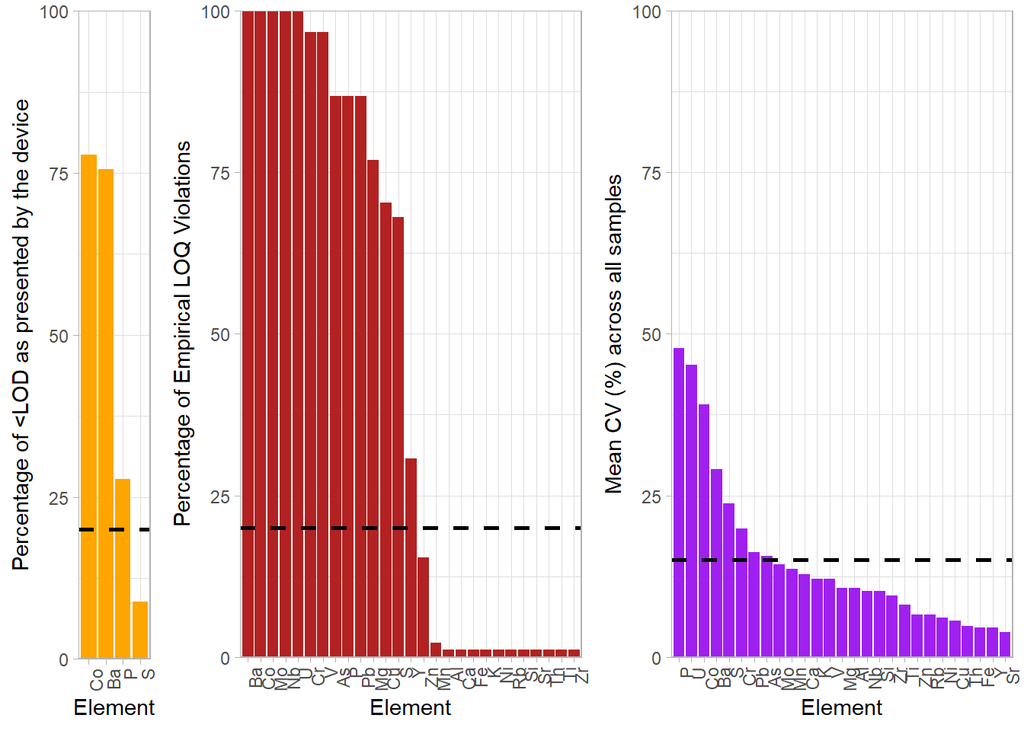

```r
# Create mean plot
mean_cv_plot <- ggplot(mean_values, aes(x = reorder(Element, -Mean_CV), y = Mean_CV)) +
  geom_bar(stat = "identity", fill = "purple") +
  labs(
    x = "Element",
    y = "Mean CV (%) across all samples"
  ) +
  theme_light() +
  scale_y_continuous(limits = c(0, 100), expand = c(0, 0)) +
  geom_hline(yintercept = 15, color = "black", linetype = "dashed", linewidth = 1) +
  theme(axis.text.x = element_text(angle = 90, hjust = 1))


# Combine LOD_plot and LOQ_plot side by side
combined_plot_LOQ_LOD_CV <- ggarrange(
  LOD_plot,
  LOQ_plot,
  mean_cv_plot,
  ncol = 3,
  widths = c(0.75,2, 2),
  align = "v"
)

# View final result
print(combined_plot_LOQ_LOD_CV)
```

```r
# Save as PDF
ggsave(
  filename = "../figures/LOD_LOQ_CV_combined.pdf",
  plot = combined_plot_LOQ_LOD_CV,
  device = "pdf",
  width = 30,
  height = 10,
  units = "cm"
)
```

### 5.5 Apply benchmark and add mean CV for elements

To adjust the benchmark, for example, to 10%, simply replace 15 with 10 in all code blocks that involve the CV calculation.

```r
# Convert values > 15 to 1, otherwise 0
Control_CV2 <- Control_CV1 %>%
  mutate(across(.cols = -SAMPLE, .fns = ~ ifelse(. > 15, 1, 0)))

# Calculate mean for each column (excluding SAMPLE)
mean_row <- Control_CV1 |>
  select(-SAMPLE) |>
  summarise(across(everything(), mean, na.rm = TRUE)) |>
  mutate(SAMPLE = "Mean")

# Add mean row to the top of the data and row SAMPLE to the front
Control_CV3 <- bind_rows(Control_CV2,mean_row)

# Round all numerical values to full numbers
Control_CV4 <- Control_CV3 %>%
  mutate(across(where(is.numeric), ~ round(.)))
```

### 5.6 Calculating violation per sample

The violating elements were defined by checking all precision criteria - LOD, LOQ and mean CV per element

```r
# Define violating elements to exclude from calculations of row percentage
violating_elements <- c("P_CV","Mg_CV","S_CV","V_CV","Cr_CV","Co_CV","Cu_CV","As_CV","Nb_CV","Mo_CV","Pb_CV","Ba_CV","U_CV")

# Define reliable elements
exclude_cols <- c("SAMPLE", "row_sum", "row_percent", violating_elements) # columns to always exclude
reliable_elements <- setdiff(names(Control_CV4), exclude_cols) # keep everything else

# Combine "SAMPLE" and violating_elements into a vector for exclusion
exclude_columns <- c("SAMPLE", violating_elements)

# Calculate the sum of each row, excluding "SAMPLE" and high percentage columns
Control_CV4$row_sum <- rowSums(Control_CV4[, !names(Control_CV4) %in% exclude_columns], na.rm = TRUE)

# Count the number of columns excluding "SAMPLE" and "Row_sum" and high percentage columns
valid_columns_count <- ncol(Control_CV4) - (length(exclude_columns)+2)

# Calculate the percentage of the Row_sum for each row based on the number of valid columns
Control_CV4$row_percent <- Control_CV4$row_sum / (valid_columns_count) * 100

# Replace the four cells in the lowest-right corner with NA
n_rows <- nrow(Control_CV4)  # Number of rows
n_cols <- ncol(Control_CV4)  # Number of columns
Control_CV4[n_rows, (n_cols - 1):n_cols] <- NA

# Round all numerical values to full numbers and sort by "row_percent" in descending order
Control_CV5 <- Control_CV4 %>%
  mutate(across(where(is.numeric), ~ round(.))) %>%
  arrange(desc(row_percent))

# print data
head(Control_CV5)
```

```
  Mg_CV Al_CV Si_CV P_CV S_CV K_CV Ca_CV Ti_CV V_CV Cr_CV Mn_CV Fe_CV Co_CV
1     1     1     1    0    1    1     1     1    1     1     1     1     0
2     1     1     1    1    0    1     1     1    1     1     1     0     0
3     0     1     1    1    0    1     1     1    1     1     1     0     0
4     1     1     1    1    0    1     1     1    1     1     1     0     1
5     1     1     1    0    1    1     1     1    1     1     1     0     0
6     0     0     1    1    0    1     1     0    0     1     0     0     1
  Ni_CV Cu_CV Zn_CV As_CV Rb_CV Sr_CV Y_CV Zr_CV Nb_CV Mo_CV Ba_CV Pb_CV Th_CV
1     0     0     0     0     1     0    0     1     1     1     0     1     0
2     0     0     0     1     1     0    0     1     1     1     1     1     0
3     0     0     0     0     1     0    0     1     1     1     1     1     0
4     0     0     0     0     0     0    0     1     1     1     1     1     0
5     0     0     0     0     0     0    0     0     0     1     0     1     0
6     0     0     0     1     0     0    0     1     0     0     0     1     0
  U_CV SAMPLE row_sum row_percent
1    0 TP_67a       9          69
2    1 TP_28a       8          62
3    1 TP_59a       8          62
4    1 TP_30a       7          54
5    1 TP_65a       6          46
6    1 TP_60b       4          31
```

### 5.7 Filtering for reliable elements and violating samples

```r
# Select reliable elements
Control_CV6 <- Control_CV5 |>
  select(all_of(reliable_elements),
         tail(names(Control_CV5), 3)) # Add the last three columns back to the selected columns

# Filter rows where "row_percent" is greater than 20 (violating samples) and sort by "row_percent" in descending order
Control_CV7 <- Control_CV6 %>%
  filter(row_percent > 20) %>%
  arrange(desc(row_percent))

# print data
print(Control_CV7)
```

```
  Al_CV Si_CV K_CV Ca_CV Ti_CV Mn_CV Fe_CV Ni_CV Zn_CV Rb_CV Sr_CV Y_CV Zr_CV
1     1     1    1     1     1     1     1     0     0     1     0    0     1
2     1     1    1     1     1     1     0     0     0     1     0    0     1
3     1     1    1     1     1     1     0     0     0     1     0    0     1
4     1     1    1     1     1     1     0     0     0     0     0    0     1
5     1     1    1     1     1     1     0     0     0     0     0    0     0
6     0     1    1     1     0     0     0     0     0     0     0    0     1
  Th_CV SAMPLE row_sum row_percent
1     0 TP_67a       9          69
2     0 TP_28a       8          62
3     0 TP_59a       8          62
4     0 TP_30a       7          54
5     0 TP_65a       6          46
6     0 TP_60b       4          31
```

**Interpretation**: This result shows that a total of six samples violate too many of the reliable elements (>20% violation of the CV benchmark) defined in above. Therefore, these samples have to be evaluated to identify the likely cause for the high variability. Re-measurements have to be undertaken.

### 5.8 Create spreadsheet with information on elements

```r
# Ensure both vectors are of the same length by adding "NA" values where necessary
max_length <- max(length(reliable_elements), length(violating_elements))

# Remove "_CV" suffix from element names
reliable_elements <- gsub("_CV$", "", reliable_elements)
violating_elements <- gsub("_CV$", "", violating_elements)

# Extend shorter vector with NA to match the max length
reliable_elements <- c(reliable_elements, rep(NA, max_length - length(reliable_elements)))
violating_elements <- c(violating_elements, rep(NA, max_length - length(violating_elements)))

# Create a named list to store the information
elements_list <- list(
  "Reliable Elements" = paste(reliable_elements, collapse = ", "),
  "Violating Elements" = paste(violating_elements, collapse = ", ")
)

# Convert the list into a data.frame (row-based)
elements <- data.frame(Name = names(elements_list), Values = unlist(elements_list), row.names = NULL, stringsAsFactors = FALSE)

# Explicitly replace any NA values with a space in the Values column
elements$Values <- gsub("NA", " ", elements$Values)

print(elements)
```

```
                Name                                               Values
1  Reliable Elements Al, Si, K, Ca, Ti, Mn, Fe, Ni, Zn, Rb, Sr, Y, Zr, Th
2 Violating Elements    P, Mg, S, V, Cr, Co, Cu, As, Nb, Mo, Pb, Ba, U,
```

### 5.9 Exporting tables

```r
# Export information on elements
write.csv(elements,"../data_analytical//Example_data_CV_elements.csv",row.names=FALSE)

# Export all elements and samples with sums and percentage as .csv
write.csv(Control_CV5,"../data_analytical//Example_data_CV_numcode_all.csv",row.names=FALSE)

# Export reliable elements and violating samples as .csv
write.csv(Control_CV7,"../data_analytical//Example_data_CV_numcode_violation.csv",row.names=FALSE)
```

## 6 Article Section 3.3 - Monitoring SCCs and %RD for device performance

### 6.1 Create Control Limits (nominal value)

**Background**

After https://stackoverflow.com/questions/39670918/replace-characters-in-column-names-gsub and https://search.r-project.org/R/refmans/base/html/Round.html

#### 6.1.1 Compute metrics of reference values

The name of the .csv-spreadsheet includes the standard the reference values are based on (SdAR-M2), month and year of measurement (March 2025 - mar2025) as well as the location (Vienna - vie): SdAR-M2_mar2025_vie.csv. This makes the file easy to identify for future use.

```r
# Load data
data1 <- read.csv("../data_analytical/SdAR-M2_mar2025_vie.csv")

# Replace '< LOD' with 0.0000001 in each column
data2 <- data1 %>%
  mutate(across(17:71, ~ case_when(
    . == "< LOD" ~ "0.0000001",
    TRUE ~ as.character(.)
  ))) %>%
  mutate(across(17:71, ~ as.numeric(.))) %>%
  mutate(across(17:71, ~ case_when(
    . >= 0.0000001 ~ . * 10000,  # Convert % to ppm
    TRUE ~ .
  ))) %>%
  mutate(across(everything(), as.numeric))  # Ensure all values are numeric

# Remove first 16 columns (no elemental data)
data <- data2[, -c(1:16)]

# Replace '.' with '_' in column names
data <- data %>%
  rename_with(~ gsub("\\.", "_", .x))

# Define statistical functions
CV <- function(x) (sd(x, na.rm = TRUE) / mean(x, na.rm = TRUE)) * 100
SEM <- function(x) sd(x, na.rm = TRUE) / sqrt(length(x))
UCL <- function(x) mean(x, na.rm = TRUE) + sd(x, na.rm = TRUE)
LCL <- function(x) mean(x, na.rm = TRUE) - sd(x, na.rm = TRUE)
CV2 <- function(x) (2*sd(x, na.rm = TRUE) / mean(x, na.rm = TRUE)) * 100
UCL2 <- function(x) mean(x, na.rm = TRUE) + 2*sd(x, na.rm = TRUE)
LCL2 <- function(x) mean(x, na.rm = TRUE) - 2*sd(x, na.rm = TRUE)
CV3 <- function(x) (3*sd(x, na.rm = TRUE) / mean(x, na.rm = TRUE)) * 100
UCL3 <- function(x) mean(x, na.rm = TRUE) + 3*sd(x, na.rm = TRUE)
LCL3 <- function(x) mean(x, na.rm = TRUE) - 3*sd(x, na.rm = TRUE)

# Define summary statistics
NominalSdARM2 <- data %>%
  summarize(across(everything(), list(
    M = ~ mean(.x, na.rm = TRUE),
    SD = ~ sd(.x, na.rm = TRUE),
    SEM = ~ SEM(.x),
    CV = ~ CV(.x),
    LCL = ~ LCL(.x),
    UCL = ~ UCL(.x),
    CV2 = ~ CV2(.x),
    LCL2 = ~ LCL2(.x),
    UCL2 = ~ UCL2(.x),
    CV3 = ~ CV3(.x),
    LCL3 = ~ LCL3(.x),
    UCL3 = ~ UCL3(.x),
    MD = ~ median(.x, na.rm = TRUE)
  )))

# Define elements
Element <- c("Si", "Ti", "Al", "Fe", "Mn", "Mg", "Ca", "K", "P", "S", "V", "Cr",
             "Ni", "Cu", "Zn", "As", "Rb", "Sr", "Y", "Zr", "Nb", "Mo", "Ba",
             "Pb", "Th", "U")

# Function to clean column names
cleanColumnNames <- function(df, prefix) {
  colnames(df) <- gsub(paste0(prefix, "_"), "", colnames(df))
  return(df)
}

# Function to extract and clean data for each element
extract_element_data <- function(element, df) {
  cols <- grep(paste0("^", element, "_(M|SD|SEM|CV|LCL|UCL|CV2|LCL2|UCL2|CV3|LCL3|UCL3|MD|Error_M|Error_SD|Error_MD)"),
               colnames(df), value = TRUE)

  if (length(cols) > 0) {
    df_out <- df %>%
      select(all_of(cols)) %>%
      cleanColumnNames(element)

    # Add the element name as the first column
    df_out <- cbind(Element = element, df_out)
    return(df_out)
  } else {
    return(data.frame(Element = element, matrix(NA, nrow = 1, ncol = length(cols))))
  }
}

# Process all elements & create final table
Tab3 <- map_dfr(Element, extract_element_data, df = NominalSdARM2)
```

#### 6.1.2 Create formated spreadsheet with all metrics

```r
# Replace "Error" with "MU" in column names
colnames(Tab3) <- gsub("Error", "MU", colnames(Tab3))

# Rounding of values
numeric_cols <- c("M", "SD", "SEM", "CV", "UCL", "LCL","CV2", "UCL2", "LCL2", "CV3",
                  "UCL3", "LCL3","MD", "MU_M", "MU_SD", "MU_MD")

for (col in numeric_cols) {
  if (col %in% colnames(Tab3)) {
    Tab3[[col]] <- round(Tab3[[col]],
                         ifelse(col %in% c("CV", "CV2", "CV3"), 2,
                                ifelse(col %in% c("UCL", "LCL", "UCL2", "LCL2", "UCL3", "LCL3"), 0, 1)))
  }
}
```

##### 6.1.2.1 Optional - adding LODs and LOQ

If you don’t want to do that, just export Tab3 (see Section 6.1.2) as it is.

```r
# Optional: Load LOD-Table and manufacturer and empirical LOD
lod_table <- read.csv("../data_analytical/Example_data_empirical_LOD_LOQ.csv")

lod_table_filtered <- lod_table %>%
  filter(grepl("_Mean$", metric)) %>%                      # keep rows ending with '_Mean'
  select(metric, Empirical_LOD, Manufacturer_LOD, Empirical_LOQ) %>%  # keep only relevant columns
  mutate(metric = gsub("_Mean$", "", metric)) %>%          # remove '_Mean' suffix
  rename(Element = metric)

# Merge into Tab3 by 'element'
Tab4 <- Tab3 %>%
  left_join(lod_table_filtered, by = "Element") %>%
  filter(!is.na(Empirical_LOD) | !is.na(Manufacturer_LOD |!is.na(Empirical_LOQ)))

print(Tab4)
```

```
   Element        M     SD    SEM    CV    LCL    UCL    CV2   LCL2   UCL2
1       Si 245939.8 9725.5 3075.5  3.95 236214 255665   7.91 226489 265391
2       Ti   1376.6   59.0   18.7  4.28   1318   1436   8.57   1259   1495
3       Al  48028.5 2005.3  634.1  4.18  46023  50034   8.35  44018  52039
4       Fe  19130.4  329.8  104.3  1.72  18801  19460   3.45  18471  19790
5       Mn    917.2   25.0    7.9  2.73    892    942   5.46    867    967
6       Mg   2628.0  326.8  103.4 12.44   2301   2955  24.87   1974   3282
7       Ca   6787.2  197.0   62.3  2.90   6590   6984   5.80   6393   7181
8        K  35574.9 1134.9  358.9  3.19  34440  36710   6.38  33305  37845
9        P    246.9   54.1   17.1 21.92    193    301  43.84    139    355
10       S   2098.0  107.5   34.0  5.12   1991   2205  10.25   1883   2313
11       V     67.6    6.9    2.2 10.28     61     75  20.55     54     81
12      Cr     43.9    5.1    1.6 11.69     39     49  23.37     34     54
13      Ni     50.3    2.4    0.7  4.69     48     53   9.38     46     55
14      Cu    287.1    4.9    1.6  1.72    282    292   3.44    277    297
```

[output cut: 66 more lines]

```r
# Save final table with all reference value metrics
write.csv(Tab4, "../data_analytical/metrics_SdAR-M2_mar2025_vie.csv", row.names = FALSE)
```

##### 6.1.2.2 Create plot Difference between Mean and LOD/LOQ

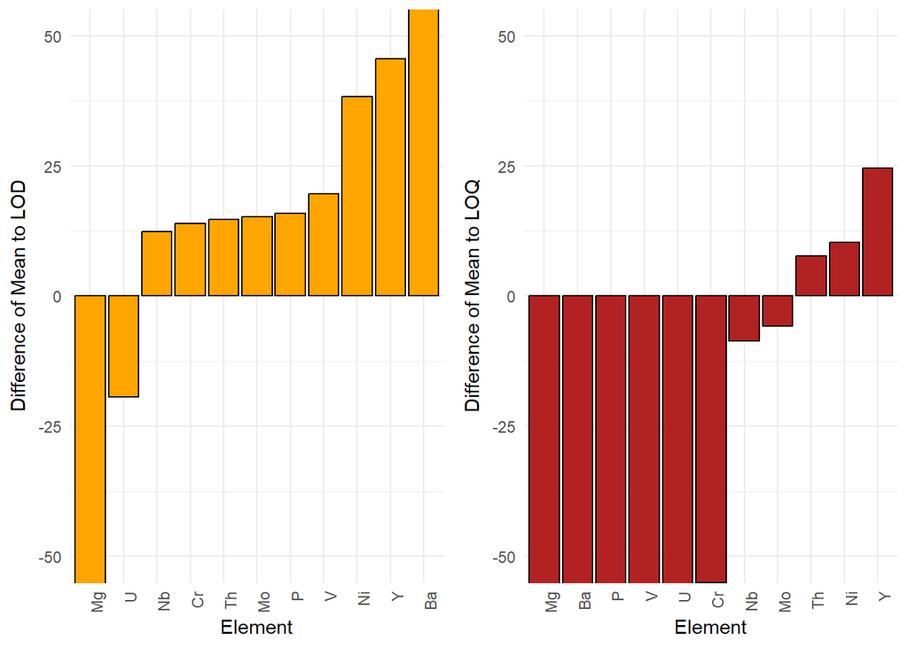

```r
Tab5 <- Tab4 %>%
  mutate(
    Diff_LOD = M - Empirical_LOD,
    Diff_LOQ = M - Empirical_LOQ
  ) %>%
  filter(Diff_LOQ < 50)

# LOD difference plot
plot_lod <- ggplot(Tab5, aes(x = reorder(Element, Diff_LOD), y = Diff_LOD)) +
  geom_col(fill = "orange", color = "black") +
  labs(
    x = "Element",
    y = "Difference of Mean to LOD"
  ) +
  coord_cartesian(ylim = c(-50, 50)) +
  theme_minimal() +
  theme(axis.text.x = element_text(angle = 90, hjust = 1))

# LOQ difference plot
plot_loq <- ggplot(Tab5, aes(x = reorder(Element, Diff_LOQ), y = Diff_LOQ)) +
  geom_col(fill = "firebrick", color = "black") +
  labs(
    x = "Element",
    y = "Difference of Mean to LOQ"
  ) +
  coord_cartesian(ylim = c(-50, 50)) +
  theme_minimal() +
  theme(axis.text.x = element_text(angle = 90, hjust = 1))


# Combine them into one row using patchwork
# Combine LOD_plot and LOQ_plot side by side
combined_hist <- ggarrange(
  plot_lod,
  plot_loq,
  ncol = 2,
  align = "hv"
)

# Print the combined plot
print(combined_hist)
```

##### 6.1.2.3 Create plot of %RD between Mean and LOD/LOQ

If you don’t want to do that, just export Tab3 (see Section 6.1.2) as it is.

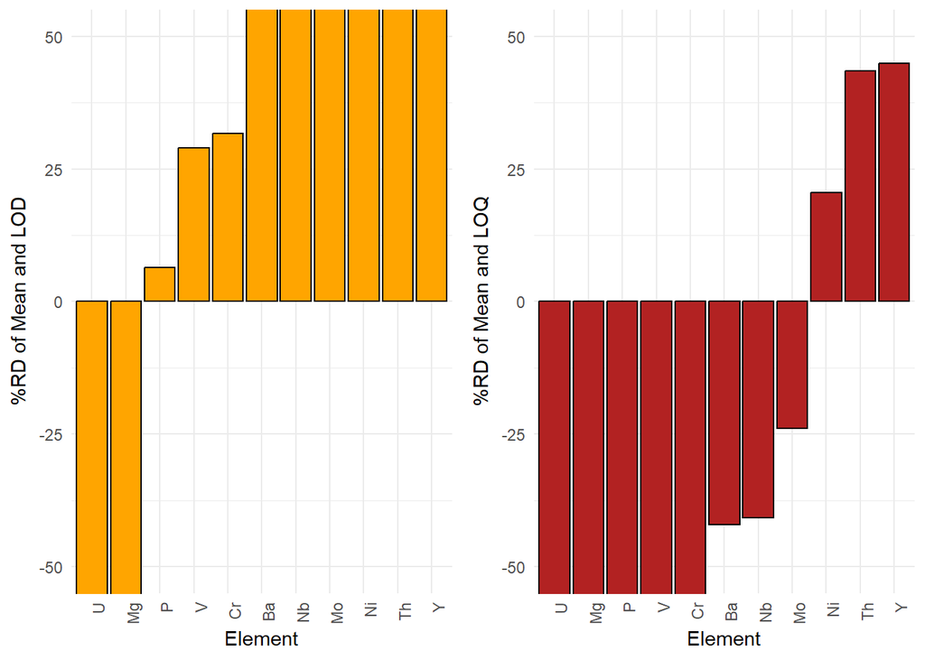

```r
Tab5 <- Tab4 %>%
  mutate(
    Diff_LOD = 100 * (M - Empirical_LOD) / M,
    Diff_LOQ = 100 * (M - Empirical_LOQ) / M
  ) %>%
  filter(Diff_LOQ < 50)

# LOD difference plot
plot_lod <- ggplot(Tab5, aes(x = reorder(Element, Diff_LOD), y = Diff_LOD)) +
  geom_col(fill = "orange", color = "black") +
  labs(
    x = "Element",
    y = "%RD of Mean and LOD"
  ) +
  coord_cartesian(ylim = c(-50, 50)) +
  theme_minimal() +
  theme(axis.text.x = element_text(angle = 90, hjust = 1))

# LOQ difference plot
plot_loq <- ggplot(Tab5, aes(x = reorder(Element, Diff_LOQ), y = Diff_LOQ)) +
  geom_col(fill = "firebrick", color = "black") +
  labs(
    x = "Element",
    y = "%RD of Mean and LOQ"
  ) +
  coord_cartesian(ylim = c(-50, 50)) +
  theme_minimal() +
  theme(axis.text.x = element_text(angle = 90, hjust = 1))


# Combine them into one row using patchwork
# Combine LOD_plot and LOQ_plot side by side
combined_hist <- ggarrange(
  plot_lod,
  plot_loq,
  ncol = 2,
  align = "hv"
)

# Print the combined plot
print(combined_hist)
```

##### 6.1.2.4 Adding LODs and LOQ for data export

If you don’t want to do that, just skip that bit.

```r
# Load data
lod_table <- read.csv("../data_analytical/Example_data_empirical_LOD_LOQ.csv")

# Filter for manufacturer and empirical LOD/LOQ
lod_table_filtered <- lod_table %>%
  filter(grepl("_Mean$", metric)) %>%                      # keep rows ending with '_Mean'
  select(metric, Empirical_LOD, Manufacturer_LOD, Empirical_LOQ) %>%  # keep only relevant columns
  mutate(metric = gsub("_Mean$", "", metric)) %>%          # remove '_Mean' suffix
  rename(Element = metric)

# Merge into Tab3 by 'element'
Tab5 <- Tab3 %>%
  left_join(lod_table_filtered, by = "Element") %>%
  filter(!is.na(Empirical_LOD) | !is.na(Manufacturer_LOD |!is.na(Empirical_LOQ)))

print(Tab5)
```

```
   Element        M     SD    SEM    CV    LCL    UCL    CV2   LCL2   UCL2
1       Si 245939.8 9725.5 3075.5  3.95 236214 255665   7.91 226489 265391
2       Ti   1376.6   59.0   18.7  4.28   1318   1436   8.57   1259   1495
3       Al  48028.5 2005.3  634.1  4.18  46023  50034   8.35  44018  52039
4       Fe  19130.4  329.8  104.3  1.72  18801  19460   3.45  18471  19790
5       Mn    917.2   25.0    7.9  2.73    892    942   5.46    867    967
6       Mg   2628.0  326.8  103.4 12.44   2301   2955  24.87   1974   3282
7       Ca   6787.2  197.0   62.3  2.90   6590   6984   5.80   6393   7181
8        K  35574.9 1134.9  358.9  3.19  34440  36710   6.38  33305  37845
9        P    246.9   54.1   17.1 21.92    193    301  43.84    139    355
10       S   2098.0  107.5   34.0  5.12   1991   2205  10.25   1883   2313
11       V     67.6    6.9    2.2 10.28     61     75  20.55     54     81
12      Cr     43.9    5.1    1.6 11.69     39     49  23.37     34     54
13      Ni     50.3    2.4    0.7  4.69     48     53   9.38     46     55
14      Cu    287.1    4.9    1.6  1.72    282    292   3.44    277    297
```

[output cut: 66 more lines]

```r
# Save final table with all reference value metrics
write.csv(Tab5, "../data_analytical/metrics_SdAR-M2_mar2025_vie.csv", row.names = FALSE)
```

#### 6.1.3 Export reference values for daily device monitoring

In the absence of guidelines for archaeological applications, elements should be chosen using the following, additional criteria: broad coverage of excitation energies, minimal peak overlaps and interferences, reliable detection (CV ≤ 10% (1δSD) ), and concentrations in the standard that meet or exceed the LOQ provided by the producer for the specific application, or if possible the empirically defined LOQ (section 2.1/3.1). Elements should also be practical to monitor as very different concentrations may be difficult to interpret due to screen limitations or rounding.

This selection only includes the relevant elements - in this example Ti, Mn, Ca (MudrockMajor) and Rb, Zn, Zr (MudrockTrace) - and the values needed to define the test range in which the measurement values should lie: Element name with UCL and LCL of the 1 SD-range, UCL2/LCL2 of the 2δSD-range and UCL3/LCL3 of the 3δSD-range. You can choose the elements to export by writing them in the code for selected_elements.

```r
# Select only necessary columns
dataset1 <- Tab3 %>% select(Element, LCL,UCL,LCL2,UCL2,LCL3,UCL3)

# Filter for the specific elements dynamically
selected_elements <- c("Ti", "Mn", "Ca", "Rb","Zn", "Zr")
dataset <- dataset1 %>% filter(Element %in% selected_elements)

write.csv(dataset, "../data_analytical/test_range_SdAR-M2_mar2025_vie.csv", row.names = FALSE)
```

**Comment**: This spreadsheet can be used to compare the mean of three standard measurements, as calculated by the device and displayed on the screen, with the test range of the selected elements. 2/3 of elements (in this case 4 of 6) have to be in the 2δSD-range for device monitoring to be positive.

### 6.2 Article Section 3.3 - Compute Shewhart Control Charts

**Background**

After https://rpubs.com/jamesonmarriott/239508 and https://cran.r-project.org/web/packages/qcc/qcc.pdf

#### 6.2.1 Create spreadsheet for Shewhart Control Charts

```r
# Transpose the data
Tab4 <- as.data.frame(t(Tab3))

# Store the original row names (before transposing)
row_names <- rownames(Tab3)

# Store the original column names (before transposing)
col_names <- colnames(Tab3)

# Assign the original row names as column names of the transposed data
colnames(Tab4) <- row_names

# Assign the original column names as row names of the transposed data
rownames(Tab4) <- col_names

# Set the first row as the column names (this will use the values of the first row as column headers)
colnames(Tab4) <- Tab4[1, ]

# Remove the first row (since it is now used as the column names)
Tab4 <- Tab4[-1, ]

# Save the table with all reference value metrics for SCC charts
write.csv(Tab4, "../data_analytical/metrics_SCC_SdAR-M2_mar2025_vie.csv", row.names = TRUE)
```

#### 6.2.2 Compute Shewhart Control Charts monitoring s-Drift

```r
# Load data
data1 <- read.csv("../data_analytical/Example_sDrift_SdAR-M2.csv")

# Replace '< LOD' with 0.0000001 in each column
data2 <- data1 %>%
  mutate(across(17:71, ~ case_when(
    . == "< LOD" ~ "0.0000001",
    TRUE ~ as.character(.)
  ))) %>%
  mutate(across(17:71, ~ as.numeric(.))) %>%
  mutate(across(17:71, ~ case_when(
    . >= 0.0000001 ~ . * 10000,  # Convert % to ppm
    TRUE ~ .
  ))) %>%
  mutate(across(everything(), as.numeric))  # Ensure all values are numeric

# Remove first 16 and the last column (no elemental data)
data <- data2[, -c(1:16,71)]

# Round data
data <- round(data, 0)

# Load data
data1 <- read.csv("../data_analytical/metrics_SCC_SdAR-M2_mar2025_vie.csv")

# Create PDF for all SCC plots
pdf("../figures/SCC_SdAR-M2_sDrift_plots.pdf", width = 8, height = 6)

# Define columns
selected_columns <- c("Si", "Ti", "Al", "Fe", "Mn", "Mg", "Ca", "K", "P", "S", "V", "Cr",
             "Ni", "Cu", "Zn", "As", "Rb", "Sr", "Y", "Zr", "Nb", "Mo", "Ba",
             "Pb", "Th", "U")

for (col in selected_columns) {

  # Extract the data for the current column
  chartdata <- data[, col]

  # Dynamically get metrics for current column from data1
  CL <- data1[1, col]
  SD <- data1[2, col]
  LCL <- data1[5, col]
  UCL <- data1[6, col]
  LCL2 <- data1[8, col]
  UCL2 <- data1[9, col]
  LCL3 <- data1[11, col]
  UCL3 <- data1[12, col]

  # Round to 0 decimal places
  CL <- round(CL, 0)
  SD <- round(SD, 0)
  LCL <- round(LCL, 0)
  UCL <- round(UCL, 0)
  LCL2 <- round(LCL2, 0)
  UCL2 <- round(UCL2, 0)
  LCL3 <- round(LCL3, 0)
  UCL3 <- round(UCL3, 0)

  # Create the control chart
  qcc_result <- qcc(
    data = chartdata,
    type = "xbar",
    nsigmas = 1,
    std.dev = SD,
    center = CL,
    rules = NULL,
    plot = FALSE
  )

  # Create the plot for the current column
    plot(qcc_result, restore.par = FALSE,
       title = paste("SCC for", col),
       ylab = "Concentration (ppm)",
       xlab = "Measurement values of SdAR-M2 of the Same Session (Day)")

  # Add 3-Sigma control limits
  abline(h = c(UCL3, LCL3), lty = 3, col = "black")
  text(x = length(chartdata) * 1, y = UCL3, labels = "UCL3", pos = 3, col = "black", cex = 0.8)
  text(x = length(chartdata) * 1, y = LCL3, labels = "LCL3", pos = 1, col = "black", cex = 0.8)

  # Add 2-Sigma control limits
  abline(h = c(UCL2, LCL2), lty = 3, col = "black")
  text(x = length(chartdata) * 1, y = UCL2, labels = "UCL2", pos = 3, col = "black", cex = 0.8)
  text(x = length(chartdata) * 1, y = LCL2, labels = "LCL2", pos = 1, col = "black", cex = 0.8)

  # Highlight points based on thresholds
  below_1sigma <- chartdata < UCL | chartdata > LCL
  below_2sigma <- chartdata > UCL | chartdata < LCL
  above_3sigma <- chartdata > UCL3 | chartdata < LCL3
  above_2sigma <- (chartdata > UCL2 & chartdata <= UCL3) | (chartdata < LCL2 & chartdata >= LCL3)

    # Overlay red points for values in 1-sigma
  points(which(below_1sigma), chartdata[below_1sigma], col = "lightgreen", pch = 19, cex = 1.2)

  # Overlay yellow points for values between 1-sigma and 2-sigma
  points(which(below_2sigma), chartdata[below_2sigma], col = "lightblue", pch = 19, cex = 1.2)

  # Overlay yellow points for values between 2-sigma and 3-sigma
  points(which(above_2sigma), chartdata[above_2sigma], col = "orange", pch = 19, cex = 1.2)

  # Overlay red points for values beyond 3-sigma
  points(which(above_3sigma), chartdata[above_3sigma], col = "red", pch = 19, cex = 1.2)

  }

# Close the PDF file
dev.off()
```

**Short-term accuracy & precision plots**

[interactive chart not shown]

**Interpretation**: Skimming through the SCCs of an example of data of the same standard taken on a single measurement day reveals very accurate results for all elements. The majority of values fall within the ±1δSD range (green), with some extending into the ±1δSD to ±2δSD range (blue). Only for Ti, Cu and Ba few values fall within the ±2δSD to ±3δSD range (yellow) therefore violating the requirements of staying inside the ±2δSD. Yet, as this appears only once in a row, no action is required (Schauer 2026). Only Mg shows twice a clear violations of all control limits and should be excluded from data analysis. Therefore, the data can be considered accurate and, in terms of in-run consistency, precise, exhibiting minimal scatter around the mean. Additionally, this scatter appears randomly distributed on either side of the mean, with no evident drift effects.

#### 6.2.3 Compute Shewhart Control Charts monitoring l-Drift

```r
# Load data
data1 <- read.csv("../data_analytical/Example_lDrift_SdAR-M2.csv")

# Transform date field
data1 <- data1 |>
  mutate(
    Time = as.POSIXct(Time, format = "%m/%d/%Y %H:%M"),  # 24-hour format
    Time = format(Time, "%Y/%m/%d/")  # Output as yyyy/mm/dd
  )

# Replace '< LOD' with 0.0000001 in each column
data2 <- data1 %>%
  mutate(across(17:71, ~ case_when(
    . == "< LOD" ~ "0.0000001",
    TRUE ~ as.character(.)
  ))) %>%
  mutate(across(17:71, ~ as.numeric(.))) %>%
  mutate(across(17:71, ~ case_when(
    . >= 0.0000001 ~ . * 10000,  # Convert % to ppm
    TRUE ~ .
  ))) %>%
  mutate(across(everything(), as.numeric))  # Ensure all values are numeric

# Remove first 16 columns (no elemental data)
data2 <- data2[, -c(1:16)]

# Combine data
data3<-cbind(data1[, c(1:16)],data2)

# Calculate mean
mean_data <- data3 %>%
  group_by(Time) %>%
  summarize(across(everything(), mean, na.rm = TRUE)) %>%
  mutate(across(where(is.numeric), ~ round(., 0)))

# Remove second to sixteenth columns and last column (no elemental data) but include Time and all measurement values
data <- mean_data[, -c(2:16,71)]

# Define Labels for plotting
time_labels <- data$Time

# Load data
data1 <- read.csv("../data_analytical/metrics_SCC_SdAR-M2_mar2025_vie.csv")

# Create PDF for all SCC plots
pdf("../figures/SCC_SdAR-M2_lDrift_plots.pdf", width = 8, height = 6)

# Define columns
selected_columns <- c("Si", "Ti", "Al", "Fe", "Mn", "Mg", "Ca", "K", "P", "S", "V", "Cr",
             "Ni", "Cu", "Zn", "As", "Rb", "Sr", "Y", "Zr", "Nb", "Mo", "Ba",
             "Pb", "Th", "U")

for (col in selected_columns) {

  # Extract the data for the current column
  chartdata <- data[, col]

  # Dynamically get metrics for current column from data1
  CL <- data1[1, col]
  SD <- data1[2, col]
  LCL <- data1[5, col]
  UCL <- data1[6, col]
  LCL2 <- data1[8, col]
  UCL2 <- data1[9, col]
  LCL3 <- data1[11, col]
  UCL3 <- data1[12, col]

  # Round to 0 decimal places
  CL <- round(CL, 0)
  SD <- round(SD, 0)
  LCL <- round(LCL, 0)
  UCL <- round(UCL, 0)
  LCL2 <- round(LCL2, 0)
  UCL2 <- round(UCL2, 0)
  LCL3 <- round(LCL3, 0)
  UCL3 <- round(UCL3, 0)

  # Create the control chart
  qcc_result <- qcc(
    data = chartdata,
    type = "xbar",
    nsigmas = 1,
    std.dev = SD,
    center = CL,
    rules = NULL,
    plot = FALSE
  )

  # Create the plot for the current column
    plot(qcc_result, restore.par = FALSE,
       title = paste("SCC for", col),
       ylab = "Concentration (ppm)",
       xlab = "Mean Values of SdAR-M2 of Different Sessions (Days)")

  # Add 3-Sigma control limits
  abline(h = c(UCL3, LCL3), lty = 3, col = "black")
  text(x = length(chartdata) * 1, y = UCL3, labels = "UCL3", pos = 3, col = "black", cex = 0.8)
  text(x = length(chartdata) * 1, y = LCL3, labels = "LCL3", pos = 1, col = "black", cex = 0.8)

  # Add 2-Sigma control limits
  abline(h = c(UCL2, LCL2), lty = 3, col = "black")
  text(x = length(chartdata) * 1, y = UCL2, labels = "UCL2", pos = 3, col = "black", cex = 0.8)
  text(x = length(chartdata) * 1, y = LCL2, labels = "LCL2", pos = 1, col = "black", cex = 0.8)

  # Highlight points based on thresholds
  below_1sigma <- chartdata < UCL | chartdata > LCL
  below_2sigma <- chartdata > UCL | chartdata < LCL
  above_3sigma <- chartdata > UCL3 | chartdata < LCL3
  above_2sigma <- (chartdata > UCL2 & chartdata <= UCL3) | (chartdata < LCL2 & chartdata >= LCL3)

    # Overlay red points for values in 1-sigma
  points(which(below_1sigma), chartdata[below_1sigma], col = "lightgreen", pch = 19, cex = 1.2)

  # Overlay yellow points for values between 1-sigma and 2-sigma
  points(which(below_2sigma), chartdata[below_2sigma], col = "lightblue", pch = 19, cex = 1.2)

  # Overlay yellow points for values between 2-sigma and 3-sigma
  points(which(above_2sigma), chartdata[above_2sigma], col = "orange", pch = 19, cex = 1.2)

  # Overlay red points for values beyond 3-sigma
  points(which(above_3sigma), chartdata[above_3sigma], col = "red", pch = 19, cex = 1.2)

  }

# Close the PDF file
dev.off()
```

**Long-term accuracy & precision plots**

[interactive chart not shown]

**Interpretation**: Evaluating the SCCs of a sample dataset from the same standard, taken over multiple measurement days, reveals highly accurate results for most elements. The majority of values fall within the ±1δSD range (green), with some extending into the ±1δSD to ±2δSD range (blue). Only for Ba and Pb each a single value falls in the ±2δSD to ±3δSD range (yellow), with Zr a single value falls outside the ±2δSD to ±3δSD range (red) therefore violating the requirements of staying inside the ±2δSD. Yet, as this appears only once, no action is required (Schauer 2026). Therefore, the data can be considered accurate and, in terms of in-run consistency, precise, exhibiting minimal scatter around the mean. Additionally, this scatter mostly appears randomly distributed on either side of the mean, with little evidence of drift effects. However, for some elements, such as Fe, Mn and Zr but especially P, S and Cr, a slight drift towards lower values may be visible while for Ni and Zn, the opposite seems the case.

### 6.3 Article Section 3.3 - Compute Relative Percentage Difference (%RD)

#### 6.3.1 Calculate %RD (l-Drift)

```r
# Load data
data1 <- read.csv("../data_analytical/Example_lDrift_SdAR-M2.csv")

# Transform date field
data1 <- data1 |>
  mutate(
    Time = as.POSIXct(Time, format = "%m/%d/%Y %H:%M"),  # 24-hour format
    Time = format(Time, "%m/%d/%Y")  # Output as mm/dd/yyyy
  )

# Replace '< LOD' with 0.0000001 in each column
data2 <- data1 %>%
  mutate(across(17:71, ~ case_when(
    . == "< LOD" ~ "0.0000001",
    TRUE ~ as.character(.)
  ))) %>%
  mutate(across(17:71, ~ as.numeric(.))) %>%
  mutate(across(17:71, ~ case_when(
    . >= 0.0000001 ~ . * 10000,  # Convert % to ppm
    TRUE ~ .
  ))) %>%
  mutate(across(everything(), as.numeric))  # Ensure all values are numeric

# Remove first 16 columns (no elemental data)
data2 <- data2[, -c(1:16)]

# Combine data
data3<-cbind(data1[, c(1:16)],data2)

# Calculate mean
mean_data <- data3 %>%
  group_by(Time) %>%
  summarize(across(everything(), mean, na.rm = TRUE)) %>%
  mutate(across(where(is.numeric), ~ round(., 0)))

# Remove second to sixteenth columns and last column (no elemental data) but include Time and all measurement values
data <- mean_data[, -c(2:16,71)]

# Load second dataset
data1 <- read.csv("../data_analytical/metrics_SCC_SdAR-M2_mar2025_vie.csv")

# Define columns
selected_columns <- c("Si", "Ti", "Al", "Fe", "Mn", "Mg", "Ca", "K", "P", "S", "V", "Cr",
                      "Ni", "Cu", "Zn", "As", "Rb", "Sr", "Y", "Zr", "Nb", "Mo", "Ba",
                      "Pb", "Th", "U")

# Loop over each selected column
for (col in selected_columns) {

  # Extract the data for the current column by name
  mean_val <- data[, col]  # This extracts the column by name (which is a string)

  # Dynamically get the reference value for the current column from data1 (assuming row 1 contains reference values)
  CL <- data1[1, col]  # Reference value for the column from data1

  # Define the percentage difference function (element-wise operation)
  percentage_difference <- function(x) {
    return(((x - CL) / CL) * 100)  # Apply the percentage difference formula
  }

  # Apply the percentage difference function to each element in mean_val
  percentage_diff <- sapply(mean_val, percentage_difference)

  # Optionally, store the result in a new column in the data
  data[, paste(col, "percentage_diff", sep = "_")] <- percentage_diff
}

# Select necessary columns, round values (except 'Time'), and remove '_percentage_diff' from column names
data_RD <- data[, c(1, 56:81)] %>%
  mutate(across(-which(names(.) == "Time"), round, 0)) %>%  # Round all columns except 'Time'
  setNames(gsub("_percentage_diff", "", colnames(.))) %>%     # Remove '_percentage_diff' from column names
  setNames(gsub("^Time$", "%RD", colnames(.)))  # Replace "Time" with "%RD"
```

##### 6.3.1.1 Optional: Add empircal LOD and data mean %RD spreadsheet

If you do not want this, just scip this bit.

```r
# Load data
ref_data <- read.csv("../data_analytical/metrics_SdAR-M2_mar2025_vie.csv")

# Extract column headers (excluding first column, e.g., "SAMPLE")
col_headers <- names(data_RD)[-1]

# Create mean and LOD vectors matching column headers
mean_row <- sapply(col_headers, function(el) {
  val <- ref_data$M[ref_data$Element == el]
  if (length(val) == 0) NA else val
})

lod_row <- sapply(col_headers, function(el) {
  val <- ref_data$Empirical_LOD[ref_data$Element == el]
  if (length(val) == 0) NA else val
})

# Build new data.frame with the two rows
new_rows <- as.data.frame(rbind(mean_row, lod_row))
new_rows <- cbind("Label" = c("Mean (ppm)", "Empirical LOD (ppm)"), new_rows)
colnames(new_rows) <- names(data_RD)

# Combine with original data
data_RD2 <- bind_rows(new_rows, data_RD)

# Round first two rows
data_RD2[1:2, -1] <- lapply(data_RD2[1:2, -1], function(x) round(as.numeric(x), 0))
```

#### 6.3.2 Format %RD-spreadsheet

If you did not add LOD-information, you will have to adjust this code so it does format the first rows as well. You will need the calculations from step Section 6.1 to run the code.

```r
# Assuming data_RD2 is your dataset
tbl <- BasicTable$new()
tbl$addData(data_RD2, firstColumnAsRowHeaders=TRUE)

# Get the number of rows and columns in the dataset
num_rows <- nrow(data_RD2)
num_columns <- ncol(data_RD2)

# Find the index of the column with the header "%RD"
rd_column_index <- which(names(data_RD2) == "%RD")

# Define the cells for which the styling needs to be applied (excluding the '%RD' column)
column_indices_to_style <- setdiff(2:num_columns, rd_column_index)

# Ensure the last row is included in styling
cells <- tbl$getCells(
  rowNumbers = 4:(num_rows + 1),
  columnNumbers = column_indices_to_style,
  matchMode = "combinations"
)

# Apply the styling
tbl$mapStyling(
  cells = cells,
  styleProperty = "background-color",
  valueType = "color",
  mapType = "logic",
  mappings = list(
    "v >= -3 & v <= 3", "lightgreen",   # Values between -3 and 3
    "v > -7 & v < -3", "lightblue",     # Values between -7 and -3
    "v > 3 & v <= 7", "lightblue",      # Values between 3 and 7
    "v > 7 & v <= 10", "yellow",        # Values between 7 and 10
    "v >= -10 & v <= -7", "yellow",      # Values between -10 and -7
    "v > 10", "firebrick",              # Values greater than 10
    "v < -10", "firebrick"            # Values less than -10
  )
)

# Render the table with the applied styles
tbl$renderTable()
```

[interactive chart not shown]

```r
# Save the table to an Excel workbook
wb <- createWorkbook(creator = Sys.getenv("M. Schauer"))
addWorksheet(wb, "Data")
tbl$writeToExcelWorksheet(wb = wb, wsName = "Data", topRowNumber = 1, leftMostColumnNumber = 1, applyStyles = TRUE)

# Save the workbook as an Excel file
saveWorkbook(wb, file = "../data_analytical/Example_relRD_SdAR-M2.xlsx", overwrite = TRUE)
```

**Interpretation**: The %RD demonstrates excellent accuracy (between -3 and +3) for the elements Fe, Ni, Cu, Zn, As, Sr, Y and Nb, with some elements — Si, Ti, Al, Mn, Ca, K, S, V, Rb, Mo and Pb — also including highly accurate %RD values (3 to 7, -3 to -7). Ba shows only one %RD values of good accuracy (7 to 10, -7 to -10), Zr one exceeding this benchmark. For Mg, P, Cr and U, the %RD values are not accurate enough (higher than 10, lower than -10). Therefore, these latter elements are not measured with sufficient accuracy and should either not be used or, if used, be handled with great care in further analysis. *This table will look different depending on the data input!* It is individual for each data set.

#### 6.3.3 Create figures of %RD

```r
# Load data and exclude first column if you added LOD-information and rename column %RD to Day
data1 <- data_RD2[-c(1, 2), ] %>%
  rename(Day = `%RD`) %>%
  mutate(across(-1, ~ as.numeric(.)))

# Define columns
selected_columns <- c("Si", "Ti", "Al", "Fe", "Mn", "Mg", "Ca", "K", "P", "S", "V", "Cr",
                      "Ni", "Cu", "Zn", "As", "Rb", "Sr", "Y", "Zr", "Nb", "Mo", "Ba",
                      "Pb", "Th", "U")

# Create a PDF file to save all plots
pdf("../figures/Example_relRD_SdAR-M2_plots.pdf", width = 10, height = 6)

# Loop through selected columns
for (col in selected_columns) {
  # Skip if column not in data1
  if (!col %in% colnames(data1)) {
    warning(paste("Skipping", col, "- not found in data1"))
    next
  }

  # Extract data
  plot_data <- data.frame(
    Day = as.factor(data1$Day),
    Value = data1[[col]]
  )

  # Create plot
  p <- ggplot(plot_data, aes(x = Day, y = Value, group = 1)) +
    geom_point() +
    geom_line() +
    geom_hline(yintercept = 0, linetype = "dashed", color = "red") +
    labs(
      title = paste("%RD-Plot for", col),
      x = "Mean Values of SdAR-M2 of different Measurement Sessions (Days)",
      y = col
    ) +
    theme_minimal() +
    theme(axis.text.x = element_text(angle = 90, hjust = 1))

  print(p)
}

# Close the PDF device
dev.off()
```

**%RD plots**

[interactive chart not shown]

## 7 Conclusions drawn from the procedures for the example data

This work-flow support the evaluation of p-XRF data precision (see Section 4 and Section 5) monitoring Limits of Detection and Limits of Quantification (Section 4), and Coefficient of Variation (CV; see Section 5) of an example dataset. Device performance (see Section 6) is assessed using Standard SdAR-M2 to generate reference values (see Section 6.1), which are used in the daily routine for device accuracy testing with Shewhart Control Charts (SCC; see Section 6.2) and the Relative Percentage Difference (%RD; see Section 6.3).

*Monitoring LOD, LOQ and CV for element precision*

Monitoring the LOD presented by the device based on the measurement mode revealed the elements Co and Ba as clearly violating the benchmark of 20% measurement values per element below LOD with P and S needing to be monitored further (see Section 4.1). Having calculated empirical LOD and LOQ (see Section 4.2), the proportion per element of values below LOQ revealed the elements Ba, Co, Mo, Nb, U, Cr, V, As, P, Pb, Mg, Cu and S to violate the 20% benchmark, while Y needs further evaluation (see Section 4.4)

*Monitoring CV for sample precision*

Applying the benchmark of not more then 20% of reliable elements per sample with a CV above 15%, for the example dataset six sample violate this requirement (see Section 5.6). Therefore, these samples have to be evaluated to identify the likely cause for the high variability. Re-measurements of these samples have to be undertaken.

*Control Limits, SCC and %RD for device monitoring*

To assess accuracy, Control Limits were calculated for Standard SdAR-M2 (see Section 6.1), defining the mean as a reference and the upper and lower control limits (±2δSD). Based on the measurement mode and matrix to be analysed, elements representative of the variability covered by the mode (energy, peak overlap etc.) have to be selected and can further be used for on-screen daily device monitoring. In this example, using a geochemical setup with a soil standard, suitable elements include the light elements Mn, Ti, and Ca (Major), and the trace elements Rb, Zn, and Zr (Trace; (see Section 6.1.3).

Monitoring device performance for short-term s-drift (see Section 6.2.2) showed consistent results for all elements, with only a few measurements violating the ±2δSD benchmark yet only once or inconsistently. No clear drift was observed, and the data scatter is random, primarily within the ±2δSD range, indicating high precision in the standard measurements. Only Mg shows to high short-term drift effects. Long-term l-drift (see Section 6.2.3) showed good consistency as well, although a few more values fell outside the ±2δSD range. The value scatter mostly appears randomly distributed on either side of the mean, with little evidence of drift effects. However, for some elements, such as Fe, Mn and Zr but especially P, S and Cr, a slight drift towards lower values is visible while for Ni and Zn, the opposite seems the case.

The %RD analysis (see Section 6.3) revealed that elements such as Mg, P and Cr were not measured with sufficient accuracy. The elements that demonstrated adequate accuracy include (see Section 6.3.2): Fe, Ni, Cu, Zn, As, Sr, Y and Nb (excellent) as well as Si, Ti, Al, Mn, Ca, K, S, V, Rb, Mo and Pb (highly accurate).

*Conclusion*

Combining the investigation in precision and accuracy of the example data, the elements that are reliable for further quantitative analysis are: Si, Ti, Al, Fe, Mn, Ca, K, Ni, Zn, Rb, Sr, Y, Zr and Th. Six samples have to be checked due to too high measurement value variability. It is important to note that the reliability of these elements may vary depending on the material and sample set being analyzed.

## 8 References

Allaire, Joseph J., Charles Teague, Carlos Scheidegger, Yihui Xie, and Christophe Dervieux. 2024. “Quarto v.1.5.55.” Edited by P. B. C. Posit Software. Boston. https://quarto.org.

ASTM International - E30.01 Committee. 2017. “Advancing Standards Transforming Markets - E30.01 Committee - ASAT E2926-17 Method for Forensic Comparison of Glass Using Micro x-Ray Fluorescence (-XRF) Spectrometry.” West Conshohocken, PA. https://doi.org/10.1520/E2926-17.

Bailiss, Christopher. 2021. “Basictabler: Construct Rich Tables for Output to ’HTML’/’excel’: R Package Version 1.0.2.” https://CRAN.R-project.org/package=basictabler.

International Association of Geoanalysts. 2017. “Reference Material Data Sheet: SdAR-M2 Metal-Rich Sediment.” https://iageo.com/wp-content/uploads/2017/11/SdAR-M2_RM_data_sheet-1.pdf.

Kassambara, Alboukadel. 2023. “Rstatix: Pipe-Friendly Framework for Basic Statistical Tests: R Package Version 0.7.2.” https://CRAN.R-project.org/package=rstatix.

R Core Team. 2024. “R v.4.4.1: A Language and Environment for Statistical Computing: Race for Your Life.” Edited by R Foundation for Statistical Computing. Vienna. https://www.R-project.org/.

RStudio Team. 2024. “RStudio v. 2024.04.2: Integrated Development Environment for r.” Edited by P. B. C. Posit Software. Boston. https://www.rstudio.com/.

Schauberger, Philipp, and Alexander Walker. 2024. “Openxlsx: Read, Write and Edit Xlsx Files: R Package Version 4.2.6.1.” https://CRAN.R-project.org/package=openxlsx.

Schauer, Michaela. 2023. “R-Scripts and Data of Coefficient Corrections Developed Since 2017 for the Niton XL3t No. 97390 Following the Munich Procedure.” Open Data LMU: Open Data LMU. https://doi.org/10.5282/ubm/data.405.

———. 2026. “Workflow and Benchmarks for Daily Device Monitoring and Data Precision Assessment in Handheld pXRF Studies.” In *Methodological Innovations in p-XRF Studies*, edited by Michaela Schauer, Nadia Cantin, and Thomas Faucher. Etudes Alexandrines. Alexandria.

Schauer, Michaela, Nadia Cantin, and Thomas Faucher, eds. 2026. *Methodological Innovations in p-XRF Studies: Conference Proceedings*. Etudes Alexandrines. Alexandria: Centre d’Etudes Alexandrines.

Scrucca, Luca. 2004. “Qcc: An r Package for Quality Control Charting and Statistical Process Control: R Package Version 1.0.2.” *R News*, no. 4/1: 11–17. https://cran.r-project.org/doc/Rnews/.

Wickham, Hadley. 2016. *Ggplot2: Elegant Graphics for Data Analysis*. 2nd ed. Use r! Cham: Springer international publishing. https://ebookcentral.proquest.com/lib/kxp/detail.action?docID=4546676.

Wickham, Hadley, and Lionel Henry. 2023. “Purrr: Functional Programming Tools: R Package Version 1.0.2.” https://CRAN.R-project.org/package=purrr.

Wickham, Hadley, Lionel Henry, Thomas Lin Pedersen, T. Jake Luciani, Matthieu Decorde, and Vaudor Lise. 2023. “Svglite: An ’SVG’ Graphics Device: R Package Version 2.1.3.” https://CRAN.R-project.org/package=svglite.

Wickham, Hadley, Jim Hester, and Jennifer Bryan. 2024. “Readr: Read Rectangular Text Data: R Package Version 2.1.5.” https://CRAN.R-project.org/package=readr.

Wickham, Hadley, Davis Vaughan, and Maximilian Girlich. 2024. “Tidyr: Tidy Messy Data: R Package Version 1.3.1.” https://CRAN.R-project.org/package=tidyr.